# Homework 09

Subhankar Ghosh

November 19, 2017

# Question 1 (Computation Time)

```r
set.seed(42)
sim_trn = mlbench.spirals(n = 2500, cycles = 1.5, sd = 0.125)
sim_trn = data.frame(sim_trn$x, class = as.factor(sim_trn$classes))
sim_tst = mlbench.spirals(n = 10000, cycles = 1.5, sd = 0.125)
sim_tst = data.frame(sim_tst$x, class = as.factor(sim_tst$classes))

set.seed(657853292)

calc_acc = function(actual, predicted) {
  mean(actual == predicted)
}

cv_5 = trainControl(method = "cv", number = 5)
oob = trainControl(method = "oob")
```

```r
set.seed(657853292)
glm_cv_time = system.time({
  sim_glm_cv  = train(
    class ~ .,
    data = sim_trn,
    trControl = cv_5,
    method = "glm")
})
best_tuning_params = c( "Not Applicable")
elapsed_tuning_time = c( glm_cv_time["elapsed"])
accuracy = c( sim_glm_cv$results$Accuracy)
glm_cv_time["elapsed"]
```

```
## elapsed
##    2.35
```

```r
set.seed(657853292)
tree_cv_time = system.time({
  sim_tree_cv = train(
    class ~ .,
    data = sim_trn,
    trControl = cv_5,
    method = "rpart")
})
best_tuning_params = c(best_tuning_params, paste("cp = ", sim_tree_cv$bestTune$cp))
elapsed_tuning_time = c(elapsed_tuning_time, tree_cv_time["elapsed"])
accuracy = c(accuracy, max(sim_tree_cv$results$Accuracy))
tree_cv_time["elapsed"]
```

```
## elapsed
##    2.58
```

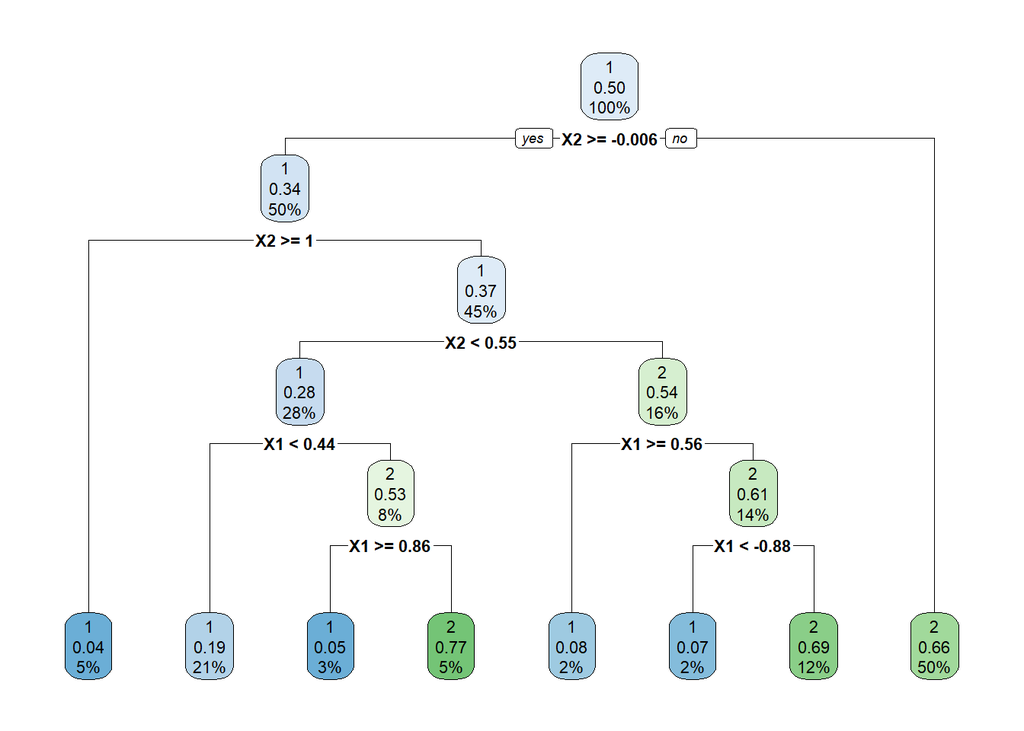

```r
rpart.plot(sim_tree_cv$finalModel)
```

```r
# Random Forest analysis
rf_grid = expand.grid(mtry = c(1, 2))

# Random Forest with CV
set.seed(657853292)
rf_cv_time = system.time({
  sim_rf_cv = train(
    class ~ .,
    data = sim_trn,
    trControl = cv_5,
    tuneGrid = rf_grid,
    method = "rf")
})
best_tuning_params = c(best_tuning_params, paste("mtry = ", sim_rf_cv$bestTune$mtry))
elapsed_tuning_time = c(elapsed_tuning_time, rf_cv_time["elapsed"])
accuracy = c(accuracy, max(sim_rf_cv$results$Accuracy))

# Random forest with oob
set.seed(657853292)
rf_oob_time = system.time({
  sim_rf_oob = train(
    class ~ .,
    data = sim_trn,
    trControl = oob,
    tuneGrid = rf_grid,
    method = "rf")
})
best_tuning_params = c(best_tuning_params, paste("mtry = ", sim_rf_oob$bestTune$mtry))
elapsed_tuning_time = c(elapsed_tuning_time, rf_oob_time["elapsed"])
accuracy = c(accuracy, max(sim_rf_oob$results$Accuracy))
elapsed_tuning_time_round = round(elapsed_tuning_time, digits = 6)

test_accuracy = c(
calc_acc(actual = sim_tst$class,
         predicted = predict(sim_glm_cv, newdata = sim_tst)),
calc_acc(actual = sim_tst$class,
         predicted = predict(sim_tree_cv, newdata = sim_tst)),
calc_acc(actual = sim_tst$class,
         predicted = predict(sim_rf_cv, newdata = sim_tst)),
calc_acc(actual = sim_tst$class,
         predicted = predict(sim_rf_oob, newdata = sim_tst))
)

out_df = rbind(best_tuning_params, elapsed_tuning_time_round, accuracy, test_accuracy)
colnames( out_df) = c("Logistic with CV", "Tree with CV", "RF with CV", "RF with OOB")

knitr::kable(out_df, align = 'c')
```

|  | Logistic with CV | Tree with CV | RF with CV | RF with OOB |
| --- | --- | --- | --- | --- |
| best_tuning_params | Not Applicable | cp = 0.0196 | mtry = 1 | mtry = 1 |
| elapsed_tuning_time_round | 2.35 | 2.58 | 22.89 | 8.28 |
| accuracy | 0.6612 | 0.748 | 0.8504 | 0.8516 |
| test_accuracy | 0.6606 | 0.7233 | 0.8512 | 0.8505 |

# Question 2 (Predicting Baseball Salaries)

```r
Hitters = na.omit(Hitters)

set.seed(657853292)
hit_idx = createDataPartition(Hitters$Salary, p = 0.6, list = FALSE)
hit_trn = Hitters[hit_idx,]
hit_tst = Hitters[-hit_idx,]

RMSE = function(actual, predicted) {
  sqrt( mean( (actual - predicted)^2 ) )
}

gbm_grid = expand.grid(interaction.depth = c(1, 2),
                       n.trees = c(500, 1000, 1500),
                       shrinkage = c(0.001, 0.01, 0.1),
                       n.minobsinnode = 10)

seat_gbm_tune = train(Salary ~ ., data = hit_trn,
                      method = "gbm",
                      trControl = cv_5,
                      verbose = FALSE,
                      tuneGrid = gbm_grid)

rf_grid = expand.grid(mtry = seq(1, ncol(hit_trn) - 1, 1))
rf_grid_bagged = expand.grid(mtry = ncol(hit_trn) - 1)

set.seed(657853292)
seat_rf_oob = train(
  Salary ~ .,
  data = hit_trn,
  trControl = oob,
  tuneGrid = rf_grid,
  method = "rf")

set.seed(657853292)
seat_rf_bagged = train(
  Salary ~ .,
  data = hit_trn,
  trControl = oob,
  tuneGrid = rf_grid_bagged,
  method = "rf")

#Creating data frame for output
Resampled_RMSE = c(seat_rf_bagged$results$RMSE, min(seat_rf_oob$results$RMSE), min(seat_gbm_tune$results$RMSE))
Test_RMSE = c(
  RMSE(actual = hit_tst$Salary,
           predicted = predict(seat_rf_bagged, newdata = hit_tst)),
  RMSE(actual = hit_tst$Salary,
           predicted = predict(seat_rf_oob, newdata = hit_tst)),
  RMSE(actual = hit_tst$Salary,
           predicted = predict(seat_gbm_tune, newdata = hit_tst))
)
Model_name = c("Bagged Tree", "Tuned Random Forest", "Tuned Boosted Tree")
out_df2 = cbind(Model_name, Test_RMSE = round(Test_RMSE, 3), Resampled_RMSE = round(Resampled_RMSE, 3))
knitr::kable( out_df2, align = 'c' )
```

| Model_name | Test_RMSE | Resampled_RMSE |
| --- | --- | --- |
| Bagged Tree | 311.906 | 290.68 |
| Tuned Random Forest | 302.989 | 281.68 |
| Tuned Boosted Tree | 337.702 | 295.542 |

# Question 3 (Transforming the Response)

```r
set.seed(657853292)
seat_rf_oob_log = train(
  log(Salary) ~ .,
  data = hit_trn,
  trControl = oob,
  tuneGrid = rf_grid,
  method = "rf")

Test_RMSE = c(
  RMSE(actual = hit_tst$Salary,
       predicted = exp(predict(seat_rf_oob_log, newdata = hit_tst))),
  RMSE(actual = hit_tst$Salary,
       predicted = predict(seat_rf_oob, newdata = hit_tst))
)

Model_name = c("Random Forest with log transform", "Random Forest without log transform")

out_df3 = cbind(Model_name, Test_RMSE = round(Test_RMSE, 3))
knitr::kable( out_df3, align = 'c' )
```

| Model_name | Test_RMSE |
| --- | --- |
| Random Forest with log transform | 308.276 |
| Random Forest without log transform | 302.989 |

# Question 4

# Timing

1. Compare the time taken to tune each model. Is the difference between the OOB and CV result for the random forest similar to what you would have expected?

**Lowest time is taken by Logistic regression with CV, followed by Tree with CV and Random Forest with Out-Of-Bag error. Highest time is taken by Random Forest with CV**

2. Compare the tuned value of mtry for each of the random forests tuned. Do they choose the same model?

**In both the cases mtry is chosen as 1 by the caret package**

3. Compare the test accuracy of each of the four procedures considered. Briefly explain these results.

**Lowest accuracy is given by logistic regression followed by single decision tree. This is because logistic regression performs better with linear boundary but since this data has non linear decision boundary trees perform better. Also Logistic regression does not take interactions into consideration automatically but the tree does it automatically, in case of any interactions between predictor variables tree must have considered it.**

# Salary

4. Report the tuned value of mtry for the random forest.

```r
seat_rf_oob$bestTune
```

```
##   mtry
## 4    4
```

**mtry = 4**

5. Create a plot that shows the tuning results for the tuning of the boosted tree model.

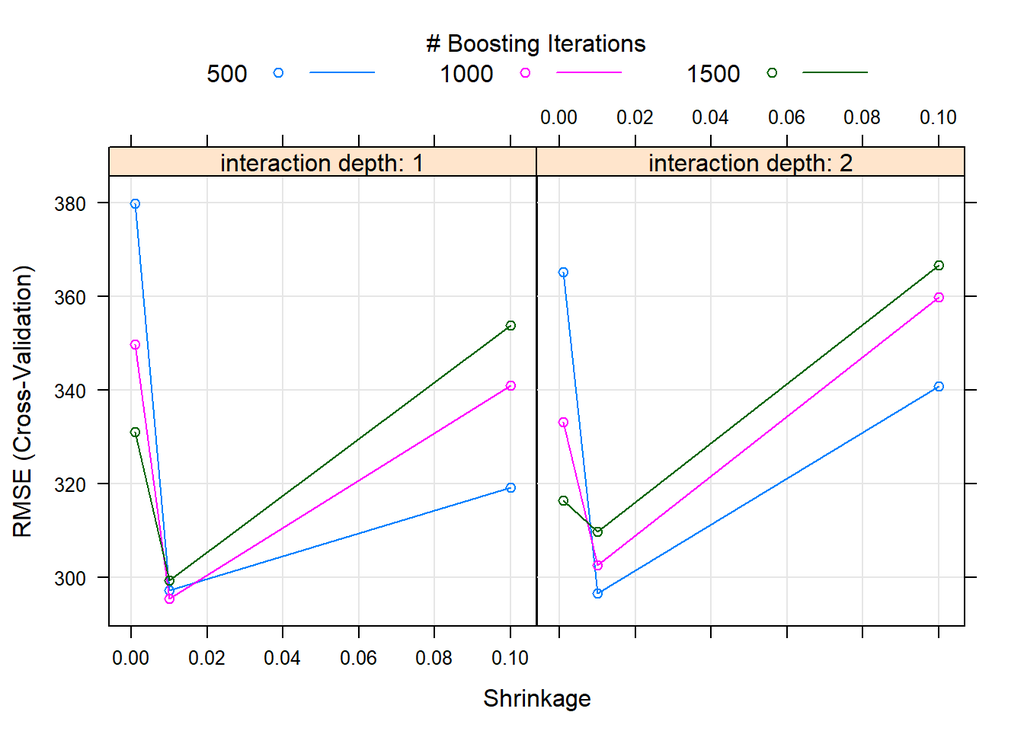

```r
plot(seat_gbm_tune)
```

6. Create a plot of the variable importance for the tuned random forest.

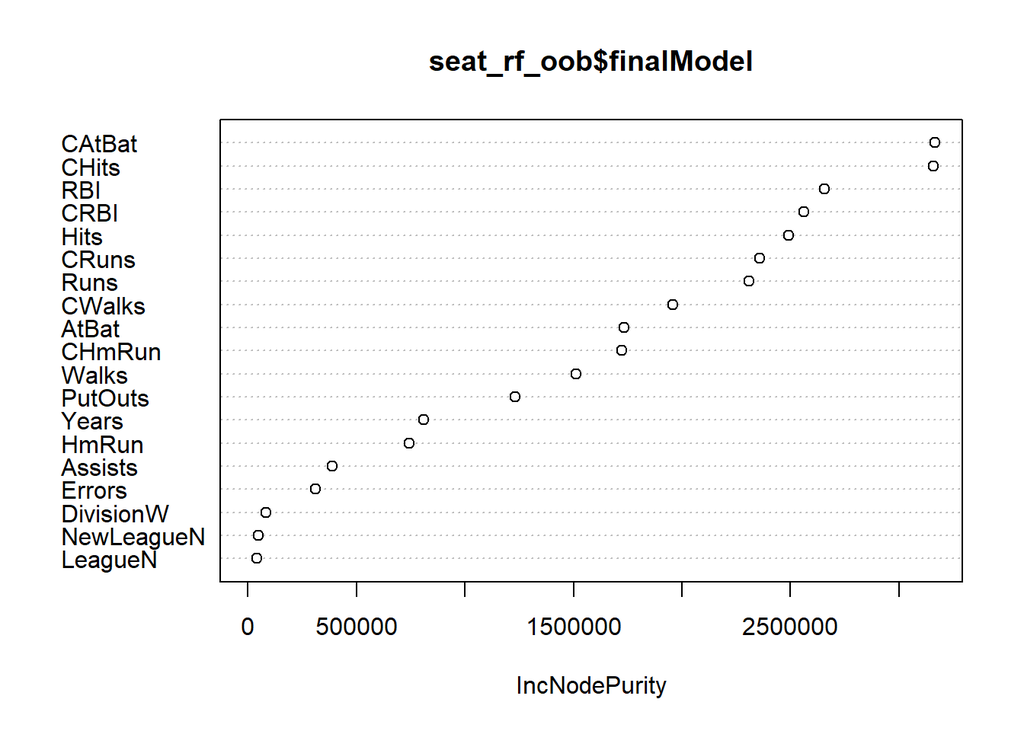

```r
varImpPlot(seat_rf_oob$finalModel, type = 2)
```

7. Create a plot of the variable importance for the tuned boosted tree model.

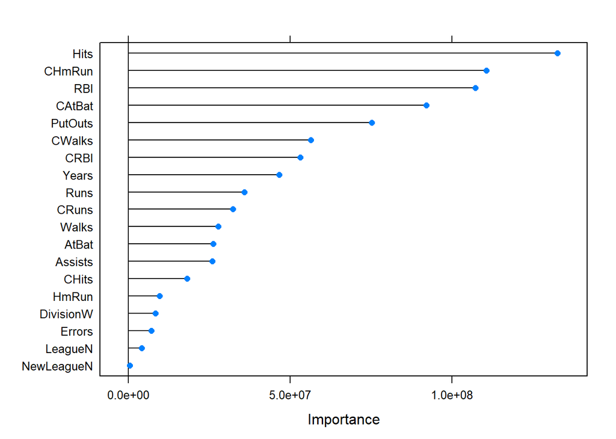

```r
gbmImp = varImp( seat_gbm_tune, scale = FALSE)
plot(gbmImp)
```

8. According to the random forest, what are the three most important predictors?

**CAtBat, CHits, RBI are the 3 most important variables according to Random Forest.**

1. According to the boosted model, what are the three most important predictors?

**Hits, CHmRun, RBI are the 3 most important variables according to the boosted model**

# Transformation

10. Based on these results, do you think the transformation was necessary?

**Based on the results the transformation was not necessary, since we get a higher Test RMSE after the transformation compared to the tuned random forest without transformations.**